# Aspects of Richmond

Chastyn Smith

```r
tracts <- read_csv("https://raw.githubusercontent.com/statsmaths/stat_data/gh-pages/acs_tract_data_2016.csv.gz")
```

```r
richmondtracts <- filter(tracts, cbsa == "Richmond, VA")
richmondtracts
```

| state | county | cbsa | lon | lat | population | hh_income_q1 | hh_income_q2 | hh_income_q3 | hh_income_q4 | hh_income_q5 | hh_income_top_5 | hh_gini | median_rent | sex_male | sex_female | age_00_17 | age_18_24 | age_25_59 | age_60_plus | race_white | race_black | race_ntvam | race_asian | race_pacif | race_other | race_multi | born_same_st | born_other_ne | born_other_midwest | … |
| --- | --- | --- | --- | --- | --- | --- | --- | --- | --- | --- | --- | --- | --- | --- | --- | --- | --- | --- | --- | --- | --- | --- | --- | --- | --- | --- | --- | --- | --- | --- |
| Virginia | Hanover County | Richmond, VA | -77.47321 | 37.74429 | 3145 | 14156 | 31244 | 51585 | 89509 | 201940 | 332412 | 0.4790 | 887 | 51.13 | 48.87 | 24.64 | 8.14 | 39.94 | 27.28 | 78.86 | 15.01 | 1.43 | 0.00 | 0.00 | 0.06 | 4.64 | 71.07 | 9.09 | 4.45 | … |
| Virginia | Hanover County | Richmond, VA | -77.42041 | 37.68215 | 5324 | 36660 | 68990 | 100310 | 145948 | 266612 | 445581 | 0.3745 | 1378 | 50.39 | 49.61 | 29.79 | 7.38 | 49.46 | 13.37 | 89.91 | 5.22 | 0.41 | 2.29 | 0.00 | 0.58 | 1.58 | 57.29 | 15.12 | 9.60 | … |
| Virginia | Henrico County | Richmond, VA | -77.62337 | 37.62710 | 4636 | 40068 | 86335 | 116946 | 162698 | 281445 | 425004 | 0.3494 | 1679 | 50.54 | 49.46 | 25.60 | 8.87 | 49.37 | 16.16 | 80.52 | 5.85 | 0.00 | 9.88 | 0.00 | 0.24 | 3.52 | 53.31 | 19.84 | 8.02 | … |
| Virginia | Henrico County | Richmond, VA | -77.51755 | 37.58984 | 3145 | 28964 | 51901 | 70820 | 99744 | 167894 | 226350 | 0.3300 | 1267 | 48.30 | 51.70 | 15.93 | 5.91 | 57.62 | 20.54 | 84.90 | 7.34 | 0.00 | 5.06 | 0.13 | 2.38 | 0.19 | 64.58 | 10.64 | 5.72 | … |
| Virginia | Henrico County | Richmond, VA | -77.44923 | 37.61916 | 2127 | 18627 | 41567 | 60575 | 85538 | 140370 | 205098 | 0.3548 | 1288 | 45.28 | 54.72 | 16.60 | 8.13 | 50.07 | 25.20 | 65.16 | 26.42 | 0.00 | 0.56 | 0.38 | 1.55 | 5.92 | 68.41 | 11.97 | 5.23 | … |
| Virginia | Henrico County | Richmond, VA | -77.30664 | 37.52248 | 3407 | 15846 | 35383 | 50039 | 63577 | 107694 | 153630 | 0.3316 | 1103 | 45.17 | 54.83 | 23.45 | 6.78 | 49.28 | 20.49 | 68.77 | 23.77 | 2.17 | 0.18 | 0.00 | 0.79 | 4.31 | 80.70 | 3.35 | 2.84 | … |
| Virginia | King William County | Richmond, VA | -77.19256 | 37.72956 | 3944 | 20810 | 43724 | 64638 | 91269 | 180859 | 359883 | 0.4028 | 1228 | 48.40 | 51.60 | 26.98 | 5.45 | 48.38 | 19.19 | 71.93 | 23.96 | 0.25 | 1.60 | 0.00 | 0.81 | 1.45 | 73.83 | 11.84 | 1.33 | … |
| Virginia | Colonial Heights city | Richmond, VA | -77.40436 | 37.25042 | 4293 | 10797 | 28861 | 46487 | 68525 | 113811 | 153211 | 0.3887 | 1009 | 46.10 | 53.90 | 24.27 | 8.78 | 48.22 | 18.73 | 77.50 | 15.16 | 0.42 | 3.07 | 0.00 | 0.30 | 3.54 | 71.37 | 6.02 | 4.41 | … |
| Virginia | Richmond city | Richmond, VA | -77.45194 | 37.57870 | 3442 | 8188 | 25737 | 57299 | 108195 | 289421 | 532317 | 0.5717 | 691 | 47.12 | 52.88 | 16.30 | 7.26 | 48.87 | 27.57 | 63.57 | 31.35 | 0.00 | 1.16 | 0.00 | 0.99 | 2.93 | 65.57 | 12.99 | 4.75 | … |
| Virginia | Richmond city | Richmond, VA | -77.40809 | 37.54204 | 1552 | 4552 | 14368 | 24758 | 44251 | 85646 | 158241 | 0.4778 | 1015 | 52.45 | 47.55 | 19.59 | 9.47 | 52.96 | 17.98 | 9.79 | 88.34 | 0.00 | 1.87 | 0.00 | 0.00 | 0.00 | 85.82 | 4.77 | 2.19 | … |

[output cut: 269 more lines]

```r
richmondcity <- filter(richmondtracts, county == "Richmond city")
richmondcity
```

| state | county | cbsa | lon | lat | population | hh_income_q1 | hh_income_q2 | hh_income_q3 | hh_income_q4 | hh_income_q5 | hh_income_top_5 | hh_gini | median_rent | sex_male | sex_female | age_00_17 | age_18_24 | age_25_59 | age_60_plus | race_white | race_black | race_ntvam | race_asian | race_pacif | race_other | race_multi | born_same_st | born_other_ne | born_other_midwest | … |
| --- | --- | --- | --- | --- | --- | --- | --- | --- | --- | --- | --- | --- | --- | --- | --- | --- | --- | --- | --- | --- | --- | --- | --- | --- | --- | --- | --- | --- | --- | --- |
| Virginia | Richmond city | Richmond, VA | -77.45194 | 37.57870 | 3442 | 8188 | 25737 | 57299 | 108195 | 289421 | 532317 | 0.5717 | 691 | 47.12 | 52.88 | 16.30 | 7.26 | 48.87 | 27.57 | 63.57 | 31.35 | 0.00 | 1.16 | 0.00 | 0.99 | 2.93 | 65.57 | 12.99 | 4.75 | … |
| Virginia | Richmond city | Richmond, VA | -77.40809 | 37.54204 | 1552 | 4552 | 14368 | 24758 | 44251 | 85646 | 158241 | 0.4778 | 1015 | 52.45 | 47.55 | 19.59 | 9.47 | 52.96 | 17.98 | 9.79 | 88.34 | 0.00 | 1.87 | 0.00 | 0.00 | 0.00 | 85.82 | 4.77 | 2.19 | … |
| Virginia | Richmond city | Richmond, VA | -77.39485 | 37.52050 | 1588 | 5662 | 16077 | 22940 | 43934 | 85863 | 116801 | 0.4551 | 689 | 46.91 | 53.09 | 30.04 | 8.75 | 48.93 | 12.28 | 24.56 | 74.06 | 0.00 | 0.00 | 0.00 | 0.76 | 0.63 | 68.28 | 12.71 | 2.54 | … |
| Virginia | Richmond city | Richmond, VA | -77.45194 | 37.54673 | 3848 | 372 | 6768 | 15492 | 27146 | 102648 | 185569 | 0.6377 | 1186 | 43.94 | 56.06 | 1.04 | 91.29 | 5.82 | 1.85 | 51.51 | 22.22 | 0.44 | 15.70 | 0.65 | 3.17 | 6.31 | 62.32 | 8.62 | 2.49 | … |
| Virginia | Richmond city | Richmond, VA | -77.48557 | 37.55634 | 1549 | 15138 | 38314 | 62307 | 90806 | 204356 | 357235 | 0.4549 | 966 | 39.38 | 60.62 | 5.87 | 7.81 | 71.59 | 14.72 | 90.45 | 4.45 | 0.00 | 1.68 | 0.00 | 0.13 | 3.29 | 60.16 | 9.65 | 6.92 | … |
| Virginia | Richmond city | Richmond, VA | -77.49769 | 37.56238 | 1465 | 18306 | 43492 | 70248 | 122229 | 316843 | 545327 | 0.5107 | 1325 | 35.84 | 64.16 | 13.17 | 5.73 | 58.29 | 22.80 | 98.09 | 0.00 | 0.00 | 0.68 | 0.00 | 0.00 | 1.23 | 53.66 | 12.61 | 7.89 | … |
| Virginia | Richmond city | Richmond, VA | -77.50869 | 37.49155 | 5442 | 10531 | 22049 | 36959 | 56753 | 102159 | 137816 | 0.4045 | 883 | 43.20 | 56.80 | 25.03 | 9.68 | 48.77 | 16.52 | 29.79 | 58.16 | 1.43 | 0.15 | 0.00 | 5.73 | 4.74 | 75.31 | 8.83 | 0.80 | … |
| Virginia | Richmond city | Richmond, VA | -77.44335 | 37.59399 | 1563 | 6312 | 16305 | 27195 | 41738 | 82016 | 117110 | 0.4334 | 828 | 43.25 | 56.75 | 34.17 | 6.27 | 41.46 | 18.11 | 5.05 | 94.11 | 0.83 | 0.00 | 0.00 | 0.00 | 0.00 | 73.25 | 11.32 | 0.39 | … |
| Virginia | Richmond city | Richmond, VA | -77.41208 | 37.52700 | 1676 | 11473 | 45976 | 72159 | 116470 | 261100 | 468725 | 0.4868 | 1255 | 59.01 | 40.99 | 8.65 | 3.28 | 70.35 | 17.72 | 62.29 | 30.79 | 0.00 | 1.55 | 0.00 | 0.00 | 5.37 | 53.97 | 14.02 | 7.23 | … |
| Virginia | Richmond city | Richmond, VA | -77.46798 | 37.55333 | 2819 | 20060 | 45177 | 73804 | 118346 | 321049 | 542130 | 0.5046 | 1010 | 45.69 | 54.31 | 11.35 | 11.00 | 62.82 | 14.83 | 91.59 | 3.30 | 0.00 | 3.87 | 0.00 | 0.89 | 0.35 | 54.62 | 24.15 | 6.80 | … |

[output cut: 54 more lines]

```r
chesterfieldcounty <- filter(richmondtracts, county == "Chesterfield County")
chesterfieldcounty
```

| state | county | cbsa | lon | lat | population | hh_income_q1 | hh_income_q2 | hh_income_q3 | hh_income_q4 | hh_income_q5 | hh_income_top_5 | hh_gini | median_rent | sex_male | sex_female | age_00_17 | age_18_24 | age_25_59 | age_60_plus | race_white | race_black | race_ntvam | race_asian | race_pacif | race_other | race_multi | born_same_st | born_other_ne | born_other_midwest | … |
| --- | --- | --- | --- | --- | --- | --- | --- | --- | --- | --- | --- | --- | --- | --- | --- | --- | --- | --- | --- | --- | --- | --- | --- | --- | --- | --- | --- | --- | --- | --- |
| Virginia | Chesterfield County | Richmond, VA | -77.56802 | 37.45978 | 2462 | 21092 | 57296 | 93235 | 147029 | 309155 | 505732 | 0.4559 | 1432 | 49.59 | 50.41 | 18.07 | 5.81 | 38.02 | 38.10 | 76.93 | 10.03 | 0.00 | 7.55 | 0.00 | 3.17 | 2.32 | 56.09 | 16.35 | 7.72 | … |
| Virginia | Chesterfield County | Richmond, VA | -77.44074 | 37.45037 | 2459 | 11268 | 25182 | 38155 | 51117 | 97116 | 164384 | 0.3831 | 840 | 50.31 | 49.69 | 28.18 | 5.25 | 52.50 | 14.07 | 60.68 | 28.10 | 0.00 | 0.00 | 0.00 | 5.53 | 5.69 | 69.89 | 7.62 | 2.79 | … |
| Virginia | Chesterfield County | Richmond, VA | -77.32350 | 37.32200 | 3884 | 24622 | 48917 | 71244 | 90700 | 140254 | 182627 | 0.3089 | 1322 | 45.91 | 54.09 | 26.11 | 10.09 | 45.26 | 18.54 | 67.25 | 22.94 | 0.00 | 2.06 | 0.00 | 5.33 | 2.42 | 62.57 | 7.69 | 5.51 | … |
| Virginia | Chesterfield County | Richmond, VA | -77.47120 | 37.38551 | 4689 | 23082 | 46830 | 65559 | 87811 | 131523 | 168628 | 0.3081 | 1162 | 48.33 | 51.67 | 21.48 | 9.28 | 50.97 | 18.28 | 72.92 | 21.18 | 0.43 | 1.83 | 0.00 | 2.13 | 1.51 | 65.28 | 9.95 | 7.34 | … |
| Virginia | Chesterfield County | Richmond, VA | -77.47620 | 37.36558 | 5609 | 26595 | 54036 | 82324 | 115743 | 211783 | 323776 | 0.3770 | 1164 | 44.38 | 55.62 | 21.04 | 6.08 | 46.02 | 26.87 | 68.00 | 30.52 | 0.00 | 0.80 | 0.00 | 0.27 | 0.41 | 54.03 | 15.16 | 6.17 | … |
| Virginia | Chesterfield County | Richmond, VA | -77.60241 | 37.51244 | 1182 | 17846 | 40386 | 54100 | 74487 | 107643 | 135299 | 0.3083 | 1076 | 44.50 | 55.50 | 22.93 | 7.02 | 55.58 | 14.47 | 71.49 | 10.58 | 0.00 | 2.71 | 0.00 | 8.88 | 6.35 | 57.47 | 11.91 | 7.63 | … |
| Virginia | Chesterfield County | Richmond, VA | -77.61411 | 37.48805 | 5700 | 32016 | 72529 | 96032 | 123654 | 273917 | 538814 | 0.3952 | 1750 | 47.81 | 52.19 | 24.98 | 3.93 | 46.35 | 24.74 | 85.61 | 9.58 | 0.21 | 2.63 | 0.00 | 0.00 | 1.96 | 53.10 | 14.68 | 8.23 | … |
| Virginia | Chesterfield County | Richmond, VA | -77.69822 | 37.38527 | 6167 | 35107 | 78366 | 102719 | 144586 | 224767 | 332248 | 0.3258 | 1171 | 49.21 | 50.79 | 33.18 | 9.40 | 49.89 | 7.52 | 78.74 | 11.51 | 0.00 | 7.41 | 0.00 | 1.04 | 1.30 | 49.49 | 24.30 | 5.94 | … |
| Virginia | Chesterfield County | Richmond, VA | -77.53514 | 37.50811 | 2324 | 11041 | 27224 | 39374 | 57230 | 120524 | 225860 | 0.4262 | 963 | 46.86 | 53.14 | 25.26 | 11.02 | 52.28 | 11.45 | 42.25 | 40.71 | 0.22 | 3.44 | 0.00 | 7.06 | 6.33 | 60.81 | 16.04 | 5.58 | … |
| Virginia | Chesterfield County | Richmond, VA | -77.44674 | 37.43863 | 2570 | 8061 | 26965 | 39685 | 56389 | 94216 | 127026 | 0.3794 | 916 | 49.61 | 50.39 | 30.58 | 12.53 | 45.53 | 11.36 | 57.39 | 22.33 | 6.46 | 0.19 | 0.00 | 10.54 | 3.07 | 83.28 | 3.83 | 1.92 | … |

[output cut: 56 more lines]

```r
henricocounty <- filter(richmondtracts, county == "Henrico County")
henricocounty
```

| state | county | cbsa | lon | lat | population | hh_income_q1 | hh_income_q2 | hh_income_q3 | hh_income_q4 | hh_income_q5 | hh_income_top_5 | hh_gini | median_rent | sex_male | sex_female | age_00_17 | age_18_24 | age_25_59 | age_60_plus | race_white | race_black | race_ntvam | race_asian | race_pacif | race_other | race_multi | born_same_st | born_other_ne | born_other_midwest | … |
| --- | --- | --- | --- | --- | --- | --- | --- | --- | --- | --- | --- | --- | --- | --- | --- | --- | --- | --- | --- | --- | --- | --- | --- | --- | --- | --- | --- | --- | --- | --- |
| Virginia | Henrico County | Richmond, VA | -77.62337 | 37.62710 | 4636 | 40068 | 86335 | 116946 | 162698 | 281445 | 425004 | 0.3494 | 1679 | 50.54 | 49.46 | 25.60 | 8.87 | 49.37 | 16.16 | 80.52 | 5.85 | 0.00 | 9.88 | 0.00 | 0.24 | 3.52 | 53.31 | 19.84 | 8.02 | … |
| Virginia | Henrico County | Richmond, VA | -77.51755 | 37.58984 | 3145 | 28964 | 51901 | 70820 | 99744 | 167894 | 226350 | 0.3300 | 1267 | 48.30 | 51.70 | 15.93 | 5.91 | 57.62 | 20.54 | 84.90 | 7.34 | 0.00 | 5.06 | 0.13 | 2.38 | 0.19 | 64.58 | 10.64 | 5.72 | … |
| Virginia | Henrico County | Richmond, VA | -77.44923 | 37.61916 | 2127 | 18627 | 41567 | 60575 | 85538 | 140370 | 205098 | 0.3548 | 1288 | 45.28 | 54.72 | 16.60 | 8.13 | 50.07 | 25.20 | 65.16 | 26.42 | 0.00 | 0.56 | 0.38 | 1.55 | 5.92 | 68.41 | 11.97 | 5.23 | … |
| Virginia | Henrico County | Richmond, VA | -77.30664 | 37.52248 | 3407 | 15846 | 35383 | 50039 | 63577 | 107694 | 153630 | 0.3316 | 1103 | 45.17 | 54.83 | 23.45 | 6.78 | 49.28 | 20.49 | 68.77 | 23.77 | 2.17 | 0.18 | 0.00 | 0.79 | 4.31 | 80.70 | 3.35 | 2.84 | … |
| Virginia | Henrico County | Richmond, VA | -77.57886 | 37.60083 | 4832 | 12116 | 30344 | 52725 | 75434 | 126073 | 169422 | 0.3889 | 1005 | 49.23 | 50.77 | 20.82 | 8.61 | 47.10 | 23.47 | 71.81 | 18.09 | 0.00 | 8.57 | 0.00 | 0.50 | 1.03 | 63.19 | 14.08 | 5.28 | … |
| Virginia | Henrico County | Richmond, VA | -77.62536 | 37.64489 | 7096 | 43355 | 78417 | 111033 | 141012 | 246960 | 395295 | 0.3265 | 1275 | 51.20 | 48.80 | 27.13 | 6.21 | 52.16 | 14.50 | 81.65 | 3.24 | 0.00 | 14.43 | 0.00 | 0.00 | 0.68 | 55.45 | 17.94 | 9.03 | … |
| Virginia | Henrico County | Richmond, VA | -77.60334 | 37.64426 | 5273 | 31389 | 64521 | 106575 | 157214 | 309976 | 544968 | 0.4197 | 1237 | 51.24 | 48.76 | 23.55 | 7.36 | 59.57 | 9.52 | 60.57 | 11.68 | 0.00 | 23.84 | 0.15 | 0.00 | 3.75 | 56.85 | 15.22 | 8.78 | … |
| Virginia | Henrico County | Richmond, VA | -77.50245 | 37.58237 | 1322 | 14682 | 40734 | 78431 | 123156 | 258672 | 417922 | 0.4731 | 1259 | 43.34 | 56.66 | 11.57 | 6.88 | 44.40 | 37.14 | 88.28 | 6.66 | 0.00 | 4.46 | 0.00 | 0.00 | 0.61 | 68.87 | 13.20 | 5.62 | … |
| Virginia | Henrico County | Richmond, VA | -77.51152 | 37.61704 | 5069 | 8515 | 21019 | 33218 | 49050 | 92110 | 143047 | 0.4111 | 955 | 48.98 | 51.02 | 21.37 | 13.91 | 45.65 | 19.08 | 59.95 | 24.58 | 0.00 | 3.12 | 0.00 | 8.21 | 4.14 | 65.84 | 14.91 | 6.22 | … |
| Virginia | Henrico County | Richmond, VA | -77.42367 | 37.59098 | 4479 | 4367 | 11665 | 26839 | 50827 | 78891 | 101247 | 0.4585 | 770 | 45.37 | 54.63 | 38.91 | 8.89 | 40.61 | 11.59 | 5.05 | 94.84 | 0.11 | 0.00 | 0.00 | 0.00 | 0.00 | 88.17 | 5.20 | 0.52 | … |

[output cut: 51 more lines]

A map of the Richmond Tract and the city of Richmond

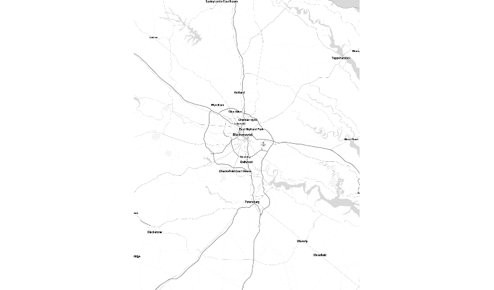

```r
qmplot(lon, lat, data = richmondtracts, geom = "blank")
```

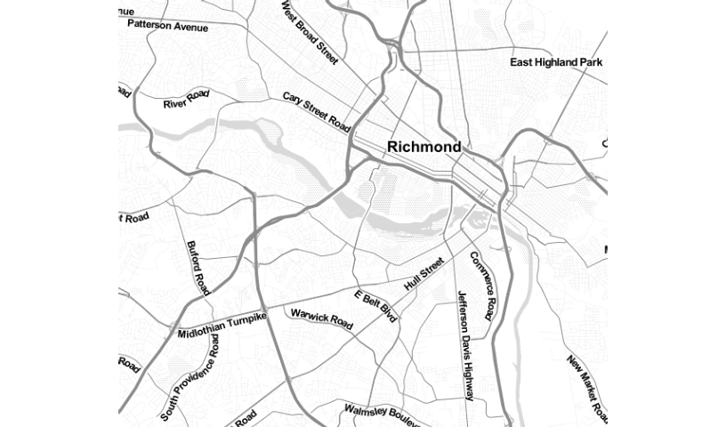

```r
qmplot(lon, lat, data = richmondcity, geom =  "blank")
```

For my project I chose the metropolitan area of Richmond, Va. I originally wanted to look at certain aspects of the city of Richmond such as race and income and compare these same aspects to those of the counties, Henrico and Chesterfield which surround Richmond. With this data I wanted to detect whether the surrounding counties had any influence on the city of Richmond in the areas of income and race. Because of how much data was provided for the city of Richmond alone I chose to go a different route. Thus, for this project I looked at population, race and income from all quadrants for the city of Richmond. I used this data to test preconceived notions about the city that I have heard and while most of the notions remained true some patterns that I did not expect arose.